# Module Seven Activity

For the module seven activity, you will identify relevant data and write Python code to generate visualizations and interpret insights from the provided data set. Professionals in data-driven fields must not only interpret data but also gather, analyze, and present it in meaningful and actionable ways. This activity allows you to practice these essential skills by working through the complete exploratory data analysis (EDA) process.

*Note:* there are two parts to this assignment. Part One is the coding activity. Part Two is the written report.

Once your code is complete, you will download this notebook as an HTML file by clicking **File**, then **Download As**, then **HTML (.html)** from the Jupyter menu bar. Validate that your code, output, and all visualizations (rendered as images using the display() function) are visible in the html file before submission.

*Missing Blocks:* Ensure that you have clicked **Run** for all blocks before downloading as an HTML file or the block may be missing from your submission. **Images** must be called using the *display()* function, for example: **display(Image(filename="output/{image_name}.png"))**

Specifically, you must address the items from the rubric criteria.

### Part One: Python Code

In this part, you will write Python code to analyze the data and generate visualizations that explore trends.

#### Create multiple, distinct visualizations that explore different aspects of the data using Python Libraries.

Include the following:

- Code comments explaining each step of your analysis

### Part Two: Report

In this part, you will write a reflection to explain the insights gained from your analysis and visualizations. *This part is to be completed in a word document, using the output here to answer the topics.*

- Explain the trends, differences, or outliers you observed in the data.
- Describe any disparities or patterns that may be relevant to the nonprofit’s goals.
- Write a summary of what the data suggests about transit usage across neighborhoods.
- Explain how the visualizations support your conclusions.
- Discuss how your findings could inform the nonprofit’s decision-making or strategy.
- Describe the importance of data-driven insights in addressing real-world challenges.

*To Begin:* This Python template program has been broken down into segments as a guide for what steps you should do at a minimum to complete this activity. Look for the **# To Do:** comments. These are placeholders for you to provide Python code segments. Fill out all **# To Do:** code segments to complete this program.  
*Once Complete:* Execute a "Kernel restart and run all" to verify that all your code works as a single unit by clicking **Kernel**, then **Restart & Run All** before downloading as html.

*Hint:* If you need to install additional packages, see one of the earlier modules on how to configure and call a requirements.txt file.

## Import the Required Packages

```python
import pandas as pd
import matplotlib.pyplot as plt
import seaborn as sns
import os
import matplotlib.image as mpimg
import matplotlib.ticker as ticker

from IPython.display import Image, display # for image rendering in html output
```

# Part One: Python Code

*Reminder:* Ensure that you add code comments explaining each step of your analysis.

## Define the file path for the dataset

```python
data_path = "data/Feb_2025_Complete_Monthly_Ridership.csv"
```

## Loading the dataset

```python
# To Do: Load the dataset
# wrap in try/except block to handle any errors
try:
    print("Loading dataset...")
    data = pd.read_csv(data_path)
    print("\tDataset loaded!")
except Exception as exception:
    print(f"ERROR: Unable to load dataset: {exception}")
```

```
Loading dataset...
	Dataset loaded!
```

## Create an output folder if it doesn't already exist

```python
output_folder = "output"
os.makedirs(output_folder, exist_ok=True)
```

## Display Dataset Information

```python
print("Dataset Overview:")
# To Do: Print the first 5 rows of the dataset to inspect the data to ensure it loaded correctly
data.head()
```

```
Dataset Overview:
```

|  | NTD ID | Legacy NTD ID | Agency | Mode | TOS | 3 Mode | Mode/Type of Service Status | Reporter Type | Organization Type | HQ City | ... | Last Closed Report Year | Last Closed FY End Month | Last Closed FY End Year | Passenger Miles FY | Unlinked Passenger Trips FY | Avg Trip Length FY | Fares FY | Operating Expenses FY | Avg Cost Per Trip FY | Avg Fares Per Trip FY |
| --- | --- | --- | --- | --- | --- | --- | --- | --- | --- | --- | --- | --- | --- | --- | --- | --- | --- | --- | --- | --- | --- |
| 0 | 1 | 0001 | King County | DR | PT | Bus | Active | Full Reporter | City, County or Local Government Unit or Depar... | SEATTLE | ... | 2023.0 | 12.0 | 2023.0 | 6,470,644 | 888,663 | 7.0 | $816,892.00 | $72,095,003.00 | $81.13 | $0.92 |
| 1 | 1 | 0001 | King County | DR | TX | Bus | Active | Full Reporter | City, County or Local Government Unit or Depar... | SEATTLE | ... | 2023.0 | 12.0 | 2023.0 | 1,509,526 | 121,496 | 12.0 | $105,605.00 | $5,658,724.00 | $46.58 | $0.87 |
| 2 | 1 | 0001 | King County | FB | DO | Ferry | Active | Full Reporter | City, County or Local Government Unit or Depar... | SEATTLE | ... | 2023.0 | 12.0 | 2023.0 | 1,479,694 | 399,687 | 4.0 | $1,493,280.00 | $8,625,721.00 | $21.58 | $3.74 |
| 3 | 1 | 0001 | King County | LR | DO | Rail | Inactive | Full Reporter | City, County or Local Government Unit or Depar... | SEATTLE | ... | 2011.0 | 12.0 | 2011.0 | 471,587 | 520,933 | 1.0 | $288,470.00 | $2,281,393.00 | $4.38 | $0.55 |
| 4 | 1 | 0001 | King County | MB | DO | Bus | Active | Full Reporter | City, County or Local Government Unit or Depar... | SEATTLE | ... | 2023.0 | 12.0 | 2023.0 | 244,710,079 | 63,485,248 | 4.0 | $60,386,305.00 | $710,359,423.00 | $11.19 | $0.95 |

5 rows × 27 columns

```python
print("Column Names:")
# To Do: Print all column names
data.columns.tolist()
```

```
Column Names:
```

```
['NTD ID',
 'Legacy NTD ID',
 'Agency',
 'Mode',
 'TOS',
 '3 Mode',
 'Mode/Type of Service Status',
 'Reporter Type',
 'Organization Type',
 'HQ City',
 'HQ State',
 'UACE CD',
 'UZA Name',
 'UZA SQ Miles',
 'UZA Population',
 'Service Area Population',
 'Service Area SQ Miles',
 'Last Closed Report Year',
 'Last Closed FY End Month',
 'Last Closed FY End Year',
 'Passenger Miles FY',
 'Unlinked Passenger Trips FY',
 'Avg Trip Length FY',
 'Fares FY',
 'Operating Expenses FY',
 'Avg Cost Per Trip FY',
 'Avg Fares Per Trip FY']
```

```python
# gather some extra info about the dataset for awareness
data.info()

# tells us: 2311 total rows, 27 columns, some null values, mostly object types
```

```
<class 'pandas.core.frame.DataFrame'>
RangeIndex: 2311 entries, 0 to 2310
Data columns (total 27 columns):
 #   Column                       Non-Null Count  Dtype
---  ------                       --------------  -----
 0   NTD ID                       2311 non-null   int64
 1   Legacy NTD ID                2224 non-null   object
 2   Agency                       2311 non-null   object
 3   Mode                         2311 non-null   object
 4   TOS                          2311 non-null   object
 5   3 Mode                       2311 non-null   object
 6   Mode/Type of Service Status  2311 non-null   object
 7   Reporter Type                2311 non-null   object
 8   Organization Type            2311 non-null   object
 9   HQ City                      2311 non-null   object
```

[output cut: 19 more lines]

```python
neighborhoods = ["King County", "City of Longview", "Spokane Transit Authority"]
# To Do: Filter the data for the three neighborhoods and create an explicit copy
neighborhood_data = data[data["Agency"].isin(neighborhoods)].copy()

# gather extra info
neighborhood_data.info()

# down to 17 total rows, no more null values
```

```
<class 'pandas.core.frame.DataFrame'>
Index: 17 entries, 0 to 48
Data columns (total 27 columns):
 #   Column                       Non-Null Count  Dtype
---  ------                       --------------  -----
 0   NTD ID                       17 non-null     int64
 1   Legacy NTD ID                17 non-null     object
 2   Agency                       17 non-null     object
 3   Mode                         17 non-null     object
 4   TOS                          17 non-null     object
 5   3 Mode                       17 non-null     object
 6   Mode/Type of Service Status  17 non-null     object
 7   Reporter Type                17 non-null     object
 8   Organization Type            17 non-null     object
 9   HQ City                      17 non-null     object
```

[output cut: 19 more lines]

```python
# To Do: Convert numeric columns to proper formats (removing commas and extra spaces)

# display a row to get a feel for how the data is stored/looks
neighborhood_data.iloc[0]
```

```
NTD ID                                                                         1
Legacy NTD ID                                                               0001
Agency                                                               King County
Mode                                                                          DR
TOS                                                                           PT
3 Mode                                                                       Bus
Mode/Type of Service Status                                               Active
Reporter Type                                                      Full Reporter
Organization Type              City, County or Local Government Unit or Depar...
HQ City                                                                  SEATTLE
HQ State                                                                      WA
UACE CD                                                                  80389.0
UZA Name                                                     Seattle--Tacoma, WA
UZA SQ Miles                                                              982.52
UZA Population                                                         3544011.0
Service Area Population                                                2347800.0
Service Area SQ Miles                                                     2134.0
Last Closed Report Year                                                   2023.0
Last Closed FY End Month                                                    12.0
Last Closed FY End Year                                                   2023.0
Passenger Miles FY                                                    6,470,644
Unlinked Passenger Trips FY                                             888,663
Avg Trip Length FY                                                           7.0
Fares FY                                                            $816,892.00
Operating Expenses FY                                            $72,095,003.00
Avg Cost Per Trip FY                                                     $81.13
Avg Fares Per Trip FY                                                     $0.92
Name: 0, dtype: object
```

```python
# strip whitespace, and remove commas
def clean_for_int(x):
    return x.strip().replace(',', '')

# strip whitespace, remove the $, and remove commas
def clean_for_float(x):
    return x.strip().replace('$', '').replace(',', '')

# convert whole number columns to ints
to_ints = ["Passenger Miles FY", "Unlinked Passenger Trips FY"]
for column in to_ints:
    neighborhood_data[column] = neighborhood_data[column].apply(clean_for_int)
    neighborhood_data[column] = neighborhood_data[column].astype(int)


# convert dollar columns to floats
to_floats = ["Fares FY", "Operating Expenses FY", "Avg Cost Per Trip FY", "Avg Fares Per Trip FY"]
for column in to_floats:
    neighborhood_data[column] = neighborhood_data[column].apply(clean_for_float)
    neighborhood_data[column] = neighborhood_data[column].astype(float)

# display the same row after cleaning
neighborhood_data.iloc[0]
```

```
NTD ID                                                                         1
Legacy NTD ID                                                               0001
Agency                                                               King County
Mode                                                                          DR
TOS                                                                           PT
3 Mode                                                                       Bus
Mode/Type of Service Status                                               Active
Reporter Type                                                      Full Reporter
Organization Type              City, County or Local Government Unit or Depar...
HQ City                                                                  SEATTLE
HQ State                                                                      WA
UACE CD                                                                  80389.0
UZA Name                                                     Seattle--Tacoma, WA
UZA SQ Miles                                                              982.52
UZA Population                                                         3544011.0
Service Area Population                                                2347800.0
Service Area SQ Miles                                                     2134.0
Last Closed Report Year                                                   2023.0
Last Closed FY End Month                                                    12.0
Last Closed FY End Year                                                   2023.0
Passenger Miles FY                                                       6470644
Unlinked Passenger Trips FY                                               888663
Avg Trip Length FY                                                           7.0
Fares FY                                                                816892.0
Operating Expenses FY                                                 72095003.0
Avg Cost Per Trip FY                                                       81.13
Avg Fares Per Trip FY                                                       0.92
Name: 0, dtype: object
```

```python
# check the Last Closed FY End Year of each row
neighborhood_data["Last Closed FY End Year"]

# notice the two that are NOT 2023, these are inactive and should be discarded
df = neighborhood_data[neighborhood_data["Last Closed FY End Year"] == 2023].copy()

# leaving us with 15 valid data points
```

## Generate, Save, and Output Visualizations

*Example Visualizations:* The three visualization placeholders below are example visualization placeholders for the data using a provided template. These are simple example frameworks that you may use, but you may, and are encouraged to develop your own visualizations that you will then explain how the selected visualizations support your conclusions in the part two report.

In accordance with the scenario, three neighborhoods for evaluation are: King County, City of Longview, and Spokane Transit Authority which have been listed in the neighborhoods variable above.

This is an example visualization you can generate. You may implement a chart and assessment of your choosing in lieu of this placeholder.

#### At a minimum include the following actions:

- Add title and axis labels
- Save the plot to a png file in the 'output' folder
- Use the display() function to render the generated png image in the html output
- Comments explaining each step of your analysis

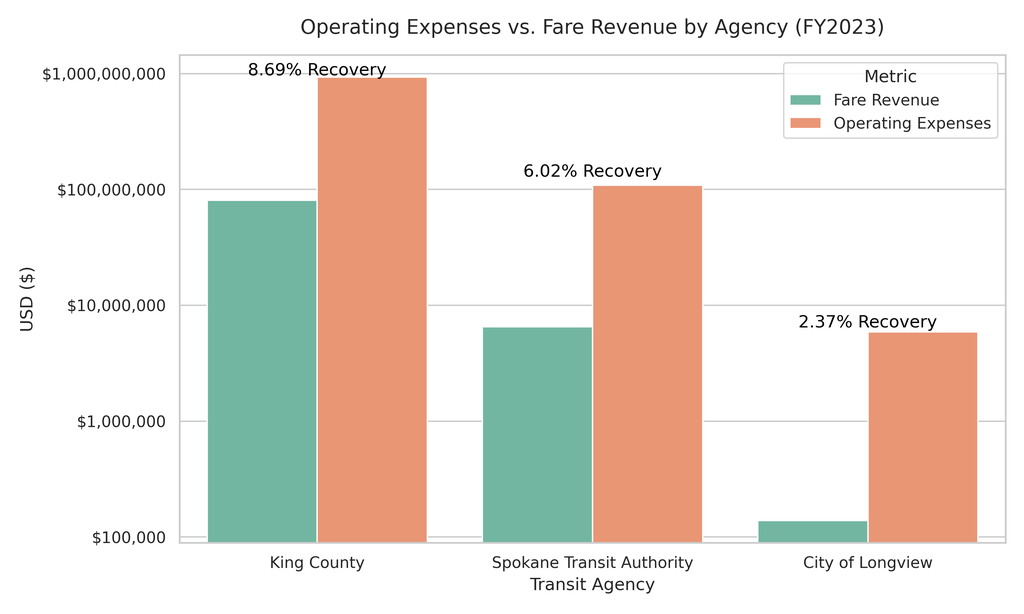

```python
# To Do: Create a visualization that will support your conclusions for part two

# VISUALIZATION 1
# Compare fare revenue and operating expenses for each of the 3 neighborhoods/agencies.

# aggregate the data by Agency
aggregated = df.groupby("Agency")[["Operating Expenses FY", "Fares FY"]].sum().reset_index()

# sort agencies by Operating Expenses descending (most expensive first)
aggregated = aggregated.sort_values(by="Operating Expenses FY", ascending=False)

# melt for a Seaborn grouped bar chart
melted = aggregated.melt(id_vars="Agency", value_vars=["Fares FY", "Operating Expenses FY"],
                         var_name="Financial Metric", value_name="USD")

# legend labels
melted["Financial Metric"] = melted["Financial Metric"].replace({
    "Fares FY": "Fare Revenue",
    "Operating Expenses FY": "Operating Expenses"
})

# set style and plot
sns.set_theme(style="whitegrid")
fig, ax = plt.subplots(figsize=(10, 6))
sns.barplot(data=melted, x="Agency", y="USD", hue="Financial Metric", ax=ax, palette="Set2")

# set the y-axis to be logarithmic since King County dwarfs the other two
plt.yscale('log')
# format the y-axis numbers with commas for clean readability
ax.get_yaxis().set_major_formatter(ticker.FuncFormatter(lambda x, p: f"${int(x):,}"))

# chart labels
ax.set_title("Operating Expenses vs. Fare Revenue by Agency (FY2023)", fontsize=14, pad=15)
ax.set_xlabel("Transit Agency", fontsize=12)
ax.set_ylabel("USD ($)", fontsize=12)
ax.legend(title="Metric")

# also want to show how much of the operating expenses are recovered by the fare revenue
# calculate the percentages
aggregated["percent"] = (aggregated['Fares FY'] / aggregated['Operating Expenses FY']) * 100
# round to 2 decimal places for presentation
aggregated["percent"] = aggregated["percent"].round(2)

# create overlay labels
percents = dict(zip(aggregated['Agency'], aggregated['percent']))
ax.text(0, 900000000, f"{percents['King County']}% Recovery", ha='center', va='bottom', color='black')
ax.text(1, 120000000, f"{percents['Spokane Transit Authority']}% Recovery", ha='center', va='bottom', color='black')
ax.text(2, 6000000, f"{percents['City of Longview']}% Recovery", ha='center', va='bottom', color='black')

# save and display!
plt.tight_layout()
image_name = "expenses_vs_revenue_by_agency_FY2023"
plt.savefig(f"output/{image_name}.png", dpi=300)
plt.close()
display(Image(filename=f"output/{image_name}.png"))
```

### Visualization 2: Bar chart comparing total ridership across neighborhoods

This is an example visualization you can generate. You may implement a chart and assessment of your choosing in lieu of this placeholder.

#### At a minimum include the following actions:

- Add title and axis labels
- Save the plot to a png file in the 'output' folder
- Use the display() function to render the generated png image in the html output
- Comments explaining each step of your analysis

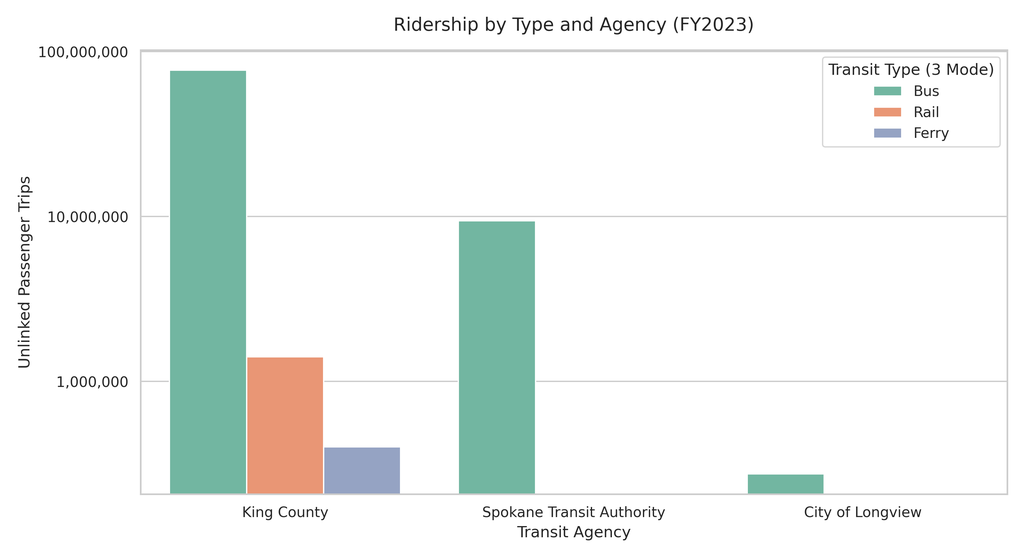

```python
# To Do: Create a visualization that will support your conclusions for part two

# VISUALIZATION 2: bar chart for total ridership by agency

# group by Agency and '3 Mode' (bus, rail, or ferry) to sum up the ridership
ridership_grouped = df.groupby(['Agency', '3 Mode'])['Unlinked Passenger Trips FY'].sum().reset_index()

# sort by ridership descending
ridership_grouped = ridership_grouped.sort_values(by='Unlinked Passenger Trips FY', ascending=False)

# plot layout
sns.set_theme(style="whitegrid")
fig, ax = plt.subplots(figsize=(11, 6))

# create the grouped bar chart, x-axis the agency and a bar for each transit type
sns.barplot(
    data=ridership_grouped,
    x='Agency',
    y='Unlinked Passenger Trips FY',
    hue='3 Mode',
    ax=ax,
    palette='Set2'
)

# log scale so King County doesn't dwarf the other two
ax.set_yscale('log')

# format y-axis as full numbers not scientific notation
ax.get_yaxis().set_major_formatter(ticker.FuncFormatter(lambda x, p: f"{int(x):,}"))

# chart labels
ax.set_title("Ridership by Type and Agency (FY2023)", fontsize=14, pad=15)
ax.set_xlabel("Transit Agency", fontsize=12)
ax.set_ylabel("Unlinked Passenger Trips", fontsize=12)
ax.legend(title="Transit Type (3 Mode)", loc='upper right')

# save and display!
plt.tight_layout()
image_name = "ridership_breakdown_FY2023"
plt.savefig(f"output/{image_name}.png", dpi=300)
plt.close()
display(Image(filename=f"output/{image_name}.png"))
```

This is an example visualization you can generate. You may implement a chart and assessment of your choosing in lieu of this placeholder.

#### At a minimum include the following actions:

- Add title and axis labels
- Save the plot to a png file in the 'output' folder
- Use the display() function to render the generated png image in the html output
- Comments explaining each step of your analysis

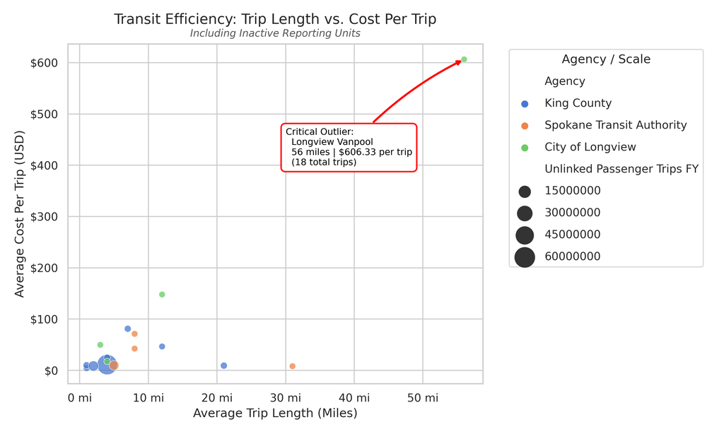

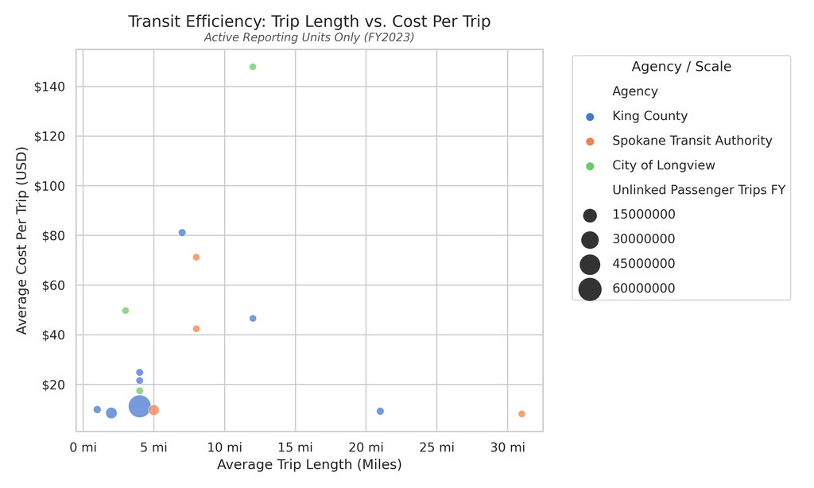

```python
# To Do: Create a visualization that will support your conclusions for part two

# VISUALIZATION 3: bubble chart for trip length vs cost and number of trips by agency
# NOTE: creating one for all 17 values and one for just FY23 to show change

# plot layout
sns.set_theme(style="whitegrid")
fig, ax = plt.subplots(figsize=(10, 6))

# bubble chart, total trips -> bubble size
sns.scatterplot(
    data=neighborhood_data,
    x='Avg Trip Length FY',
    y='Avg Cost Per Trip FY',
    hue='Agency',
    size='Unlinked Passenger Trips FY',
    sizes=(40, 400),  # sets the min and max bubble sizes
    alpha=0.75, # transparency for overlapping bubbles
    palette='muted',
    ax=ax
)

# format y-axis for dollar amounts
ax.get_yaxis().set_major_formatter(ticker.FuncFormatter(lambda x, p: f"${int(x)}"))
# format x-axis for miles
ax.xaxis.set_major_formatter(ticker.FuncFormatter(lambda x, p: f"{int(x)} mi"))

# chart labels
ax.set_title("Transit Efficiency: Trip Length vs. Cost Per Trip", fontsize=14, pad=20)
ax.text(0.5, 1.03, "Including Inactive Reporting Units", fontsize=10, color='#555555', style='italic', ha='center', va='center', transform=ax.transAxes)
ax.set_xlabel("Average Trip Length (Miles)", fontsize=12)
ax.set_ylabel("Average Cost Per Trip (USD)", fontsize=12)

# make sure legend doesn't overlap plot
ax.legend(bbox_to_anchor=(1.05, 1), loc='upper left', title="Agency / Scale", labelspacing=1)

# add a callout for the Longview outlier, which is the focal point of this chart
ax.annotate(
    "Critical Outlier:\n  Longview Vanpool\n  56 miles | $606.33 per trip\n  (18 total trips)",
    xy=(56, 606.33),
    xytext=(30, 400),
    textcoords='data',
    fontsize=9,
    color='black',
    bbox=dict(boxstyle="round,pad=0.5", fc="white", ec="red", lw=1.5, alpha=0.9),
    arrowprops=dict(arrowstyle="->", connectionstyle="arc3,rad=-0.1", color="red", lw=2)
)

# save and display!
plt.tight_layout()
image_name = "trip_length_vs_cost"
plt.savefig(f"output/{image_name}.png", dpi=300)
plt.close()
display(Image(filename=f"output/{image_name}.png"))

# create the second chart (not including inactive rows)
# plot layout
sns.set_theme(style="whitegrid")
fig, ax = plt.subplots(figsize=(10, 6))

# bubble chart, total trips -> bubble size
sns.scatterplot(
    data=df,
    x='Avg Trip Length FY',
    y='Avg Cost Per Trip FY',
    hue='Agency',
    size='Unlinked Passenger Trips FY',
    sizes=(40, 400),  # sets the min and max bubble sizes
    alpha=0.75, # transparency for overlapping bubbles
    palette='muted',
    ax=ax
)

# format y-axis for dollar amounts
ax.get_yaxis().set_major_formatter(ticker.FuncFormatter(lambda x, p: f"${int(x)}"))
# format x-axis for miles
ax.xaxis.set_major_formatter(ticker.FuncFormatter(lambda x, p: f"{int(x)} mi"))

# chart labels
ax.set_title("Transit Efficiency: Trip Length vs. Cost Per Trip", fontsize=14, pad=20)
ax.text(0.5, 1.03, "Active Reporting Units Only (FY2023)", fontsize=10, color='#555555', style='italic', ha='center', va='center', transform=ax.transAxes)
ax.set_xlabel("Average Trip Length (Miles)", fontsize=12)
ax.set_ylabel("Average Cost Per Trip (USD)", fontsize=12)

# make sure legend doesn't overlap plot
ax.legend(bbox_to_anchor=(1.05, 1), loc='upper left', title="Agency / Scale", labelspacing=1)

# save and display!
plt.tight_layout()
image_name = "trip_length_vs_cost_FY2023"
plt.savefig(f"output/{image_name}.png", dpi=300)
plt.close()
display(Image(filename=f"output/{image_name}.png"))
```